# Inverting Laguerre Tessellations: Recovering tessellations from the volumes and centroids of their cells using optimal transport

This notebook contains the code for creating the examples in the following paper:

Bourne, D.P., Pearce, M. & Roper, S.M. (2024) Inverting Laguerre tessellations: Recovering tessellations from the volumes and centroids of their cells using optimal transport, *arXiv:2406.00871*, [PDF](https://arxiv.org/abs/2406.00871)

## 1. Install and import libraries

We rely on the library pysdot to solve optimal transport problems.

```python
#@title If running in Google Colab, install pysdot and vtk
RunningInCOLAB = 'google.colab' in str(get_ipython())
if RunningInCOLAB:
    !pip install pysdot > install_pysdot.log
    !pip install vtk > install_vtk.log
```

Import libraries:

```python
#@title Import libraries

import numpy as np
from scipy.optimize import minimize
from scipy.spatial.distance import cdist

# Plotting
import matplotlib.pyplot as plt

# pysdot
from pysdot.domain_types import ConvexPolyhedraAssembly
from pysdot import OptimalTransport
from pysdot import PowerDiagram

# vtk
import vtk
from vtk.numpy_interface import dataset_adapter as dsa
from vtk.util.numpy_support import vtk_to_numpy

# Data handling
import pandas as pandas
```

## 2. Functions

### 2.1 Objective functions

In this section we define the objective functions $f$ and $H$, which are defined in equations (3.1) and (4.1) [here](https://arxiv.org/pdf/2406.00871). In order to do this, we first define functions for evaluating the optimal transport cost $W_2^2(1,\sum_i v_i \delta_{x_i})$; see equation (4.2) [here](https://arxiv.org/pdf/2406.00871).

```python
#@title Functions for solving the semi-discrete optimal transport problem

def init_w(x,om):
    """
    This function generates a weight vector w so that the Laguerre tessellation
    of the box om generated by the seeds x and the weights w has cells of
    positive area. It uses the rescaling method from Section 2.2 of the
    following paper:
    J. Meyron. Initialization procedures for discrete and semi-discrete
    optimal transport. Computer-Aided Design, 115:13–22, 2019.

    Inputs:
        x  - seeds, (n,2) numpy array
        om - domain, pysdot ConvexPolyhedraAssembly (assumed to be a rectangle)

    Outputs:
        w - weights of the Laguerre diagram, (n,) numpy array

    """

    # Centroid of the rectangular domain
    com = 0.5 * ( om.max_position() + om.min_position() )

    # Width and height of the rectangular domain
    Lx = om.max_position()[0] - om.min_position()[0]
    Ly = om.max_position()[1] - om.min_position()[1]

    # Define a dilation factor l and a translation t so that the transformed
    # seeds X = l*(x-com) + com = l*x + t lie inside the box. We choose to map
    # the 1st seed to the centre of mass (com) of the box. All the other seeds
    # are dilated about the centre of mass so that they lie inside the box.
    alpha = 0.49
    l = alpha * np.min([Lx,Ly]) / np.max(np.abs(x-x[0,:]))
    t = com - l*x[0,:]

    # The corresponding weight w for the original seeds
    # (see Lemma 2.1 in https://arxiv.org/pdf/2406.00871)
    w = -2.*np.sum(t*x,axis=1) - (l-1.)*np.sum(x*x,axis=1)

    return w

def solve_OT_problem(x,v,om):
    """
    This function uses pysdot to solve the semi-discrete optimal transport
    problem with source measure equal to the Lebesgue measure on the domain om
    and target measure equal to \sum_i v_i \delta_{x_i}.

    Inputs:
        x  - seeds, (n,2) numpy array
        v  - areas, (n,) numpy array
        om - domain, pysdot ConvexPolyhedraAssembly (assumed to be a rectangle)

    Outputs:
        w - weights of the Laguerre diagram, (n,) numpy array
        c - centroids of the Laguerre cells, (n,2) numpy array

    """

    # Error tolerance for the OT solver
    err_tol = 1e-3*np.min(v)

    # Generate initial weights such that all cells have positive area
    w0 = init_w(x,om)

    # Initialise the optimal transport problem
    ot = OptimalTransport(positions = x, masses = v, weights = w0, domain = om,
                          obj_max_dm = err_tol, verbosity = 0,
                          linear_solver = 'Scipy')

    # Solve the optimal transport problem
    ot.adjust_weights()

    # Get cell data
    c = ot.get_centroids() # centroids of the cells
    av = ot.pd.integrals() # areas of the cells
    w = ot.get_weights() # weights

    # Difference between the true areas and target areas
    dv = np.max( np.abs(v-av) )

    # Error message if dv > tolerance
    if dv > err_tol:
        print('Maximum error in volume ',dv)
        raise('Volume tolerance not met')

    return w, c
```

The following function computes the objective function $H$ and its gradient; see equation (4.1) [here](https://arxiv.org/pdf/2406.00871).

```python
#@title The objective function $H$
def compute_H_dH(x,b,v,om):
    """
    This function evaluates the concave function H defined in equation (4.1) in
    this paper: https://arxiv.org/pdf/2406.00871

    Inputs:
        x  - seeds, (n,2) numpy array
        b  - target centroids, (n,2) numpy array
        v  - target areas, (n,) numpy array
        om - domain, pysdot ConvexPolyhedraAssembly (assumed to be a rectangle)

    Outputs:
        H  - value of H, float
        dH - gradient of H, (n,) numpy array

    """

    w, c = solve_OT_problem(x,v,om)

    # Compute H and its gradient (assuming that the seeds are distinct)
    H = np.sum( v*np.sum((b-c)*x, axis=1) )
    dH = v.reshape(-1,1)*(b-c)

    return H, dH
```

The following functions compute the objective function $f$; see equation (3.1) [here](https://arxiv.org/pdf/2406.00871).

```python
#@title The objective function $f$ (least squares error)

def normalisation(vol,n):
    return (vol ** 3)/(n ** 2)

def compute_F(x,b,v,om):
    """
    This function evaluates the normalised least squares error defined
    in equation (5.2) in this paper: https://arxiv.org/pdf/2406.00871

    Input:
        x  - seeds, (n,2) numpy array
        b  - target centroids, (n,2) numpy array
        v  - target areas, (n,) numpy array
        om - domain, pysdot ConvexPolyhedraAssembly (assumed to be a rectangle)

    Output:
        f  - value of f (normalised), float
    """

    w, c = solve_OT_problem(x,v,om)

    #  Compute f
    f  =  (np.linalg.norm(v.reshape(-1,1)*(b-c)) ** 2) / normalisation(om.measure(),v.size)

    return f
```

### 2.2. Constraint functions

First we define the constraint functions $c_{ij}$, which are defined in Section 5.1 [here](https://arxiv.org/pdf/2406.00871). The constraint $c_{ij}(\mathbf{X}) \ge 0$ ensures that the distance between the $i$-th and $j$-th seeds is greater than a prescribed tolerance.

```python
#@title Pairwise distance constraint $c_{ij} \ge 0 \; \forall \; i,j$

def pairwise(x,delta):
    """
    This function evaluates the constraint function
    0.5*c_{ij} = 0.5*(|x_i-x_j|^2-delta^2) for each i,j distinct.

    Inputs:
        x - seeds, (n,2) numpy array
        delta - minimum distance between seeds, float

    Outputs:
          - value of the constraint function, (N*(N-1)/2,) numpy array

    """

    tmp = cdist(x,x) # cdist imported from scipy
    indices = np.tril_indices_from(tmp,k=-1)
    pd = np.asarray(tmp[indices])

    return 0.5*(pd**2-delta**2)

def Dpairwise(x):
    """
    Gradient of the constraint function pairwise, i.e., the derivative of
    0.5*(|x_i-x_j|^2-delta^2) with respect to x_k.

    Inputs:
        x - seeds, (n,2) numpy array

    Outputs:
          - gradient of the constraint function, (N*(N-1)/2,N,2) numpy array

    """

    tmp = cdist(x,x)
    n_seeds = np.shape(x)[0]
    indices = np.tril_indices_from(tmp,k=-1)
    pd = np.asarray(tmp[indices])
    n_constraints = np.size(pd)
    J = np.zeros((n_constraints,n_seeds,2))

    for k in range(n_constraints):
        ind0 = indices[0][k];ind1=indices[1][k]
        J[k,ind0,:] = x[ind0,:]-x[ind1,:]
        J[k,ind1,:] = x[ind1,:]-x[ind0,:]

    return J
```

Now we define the constraint function $c_{\mathrm{ball}}$, which is defined in Section 5.1 [here](https://arxiv.org/pdf/2406.00871). The constraint $c_{\mathrm{ball}}(\mathbf{X}) \ge 0$ ensures that the the seeds are confined to a compact set.

```python
#@title Ball constraint $c_{\textrm{ball}} \ge 0$

def constraint_ball(x,x0,R):
    """
    This function evaluates the constraint function 0.5(R^2-\sum_i|x_i-x_0|^2).

    Inputs:
        x  - seeds, (n,2) numpy array
        x0 - centre of ball in \mathbb{R}^{2N} is (x0,....,x0), (1,2) numpy array
        R  - radius of ball in \mathbb{R}^{2N}, float

    Outputs:
           - value of the constraint function, float
    """

    return 0.5*(R**2 - np.linalg.norm(x-x0)**2)

def Dconstraint_ball(x,x0):
    """
    Gradient of the constraint function constraint_ball, i.e., the
    derivative of 0.5(R^2-\sum_i|x_i-x_0|^2) with respect to x_k.

    Input:
        x  - seeds, (n,2) numpy array
        x0 - centre of ball in \mathbb{R}^{2N} is (x0,....,x0), (1,2) numpy array

    Output:
           - gradient of the constraint function, (n,2) numpy array
    """

    return x0 - x
```

### 2.3 Optimisation routines

The following function minimises the least squares error $f$ subject to the constraints $c_{ij} \ge 0$ for all $i,j$. To be precise, it solves the constrained optimisation problem stated in equation (5.2) [here](https://arxiv.org/pdf/2406.00871).

```python
#@title Function to minimise $f$

def min_F_solver(xinit, b, v, om, d = 1e-3, max_iter = 100, ptol = 1e-2,
                 verbosity = True, table = None):
    """
    This function solves the constrained optimisation problem stated in
    equation (5.2) here: https://arxiv.org/pdf/2406.00871
    """

    # Number of seeds
    n = v.size

    # Define the objective function. It takes as input a (2*n,) numpy array.
    objective_fun = lambda x: compute_F(np.reshape(x,(n,2)),b,v,om)

    # Define the constraint function. It takes as input a (2*n,) numpy array.
    scipy_pairwise = lambda x: pairwise(np.reshape(x,(-1,2)),d)

    # Define the gradient of the constraint function.
    def scipy_pairwise_jac(x):
        return np.reshape(Dpairwise(np.reshape(x,(-1,2))),(n*(n-1)//2,2*n))

    pair_con = {'type': 'ineq',
               'fun' : scipy_pairwise,
               'jac' : scipy_pairwise_jac}

    # Calculate ftol based on ptol and the initial value of f.
    Finit = objective_fun(xinit.flatten()) # initial value of objective function
    ftol = Finit*ptol
    print("Intial value of f is", Finit)

    # Formatting the data.
    if table is None:
        # Construct column names
        columns = ["f","MinPairwise"]

        # Creata a pandas dataframe with the column titles above
        table = pandas.DataFrame(columns = columns)

        # Populate the first row of data with initial data
        table.loc[0] = [Finit,np.min(pairwise(xinit,d))]

    # Function to write to the table + print to display on each iteration
    def callbackF(Xi):
        Nit = len(table.index)
        table.loc[Nit] = [objective_fun(Xi),np.min(scipy_pairwise(Xi))]
        if verbosity:
            print(f"{Nit}: f = {table.iloc[-1,0]}, minPairwise={table.iloc[-1,1]}")

    # Solve the optimisation problem using the function scipy.optimize.minimize
    res = minimize(objective_fun, xinit.flatten(), method='SLSQP',
                   constraints = pair_con, callback = callbackF,
                   options = {'ftol': ftol, 'disp': True, 'maxiter': max_iter})

    # Reshape the final iterate into an (n,2) numpy array
    Xf = np.reshape(res.x,(-1,2))

    return table, Xf
```

The following function maximises $H$ subject to the constraints $c_{ij} \ge 0$ for all $i,j$ and $c_{\mathrm{ball}} \ge 0$. To be precise, it solves the constrained optimisation problem stated in equation (5.1) [here](https://arxiv.org/pdf/2406.00871).

```python
#@title Function to maximise $H$

def max_H_solver(xinit,b,v,om,R0=1,d=1e-3,max_iter=100,ptol=1e-6,verbosity=True,table = None):
    """
    This function solves the constrained optimisation problem stated in
    equation (5.1) here: https://arxiv.org/pdf/2406.00871
    """

    # Number of seeds
    n = v.size

    # Centroid of the box
    x0 = 0.5*(om.max_position()+om.min_position())

    # Define the objective function. It takes as input a (2*n,) numpy array.
    objective_fun = lambda x:-compute_H_dH(np.reshape(x,(n,2)),b,v,om)[0]

    # Define the gradient of the objective function.
    Dobjective_fun = lambda x: -np.reshape(compute_H_dH(np.reshape(x,(n,2)),b,v,om)[1],-1)

    # Define the pairwise constraint function. It takes as input a (2*n,) numpy array.
    scipy_pairwise = lambda x: pairwise(np.reshape(x,(-1,2)),d)

    # Define the gradient of the pairwise constraint function.
    def scipy_pairwise_jac(x):
        return np.reshape(Dpairwise(np.reshape(x,(-1,2))),(n*(n-1)//2,2*n))

    pair_con = {'type': 'ineq',
               'fun' : scipy_pairwise,
               'jac' : scipy_pairwise_jac}

    # Define the ball constraint function. It takes as input a (2*n,) numpy array.
    scipy_constraint_ball = lambda x: constraint_ball(np.reshape(x,(n,2)), x0, R0)

    # Define the gradient of the ball constraint function.
    scipy_constraint_ball_jac = lambda x: np.reshape(Dconstraint_ball(np.reshape(x,(n,2)),x0),(1,-1))

    ball_con = {'type': 'ineq',
                'fun': scipy_constraint_ball,
                'jac': scipy_constraint_ball_jac}

    cons = [pair_con,ball_con]

    # Define the least squares error. It takes as input a (2*n,) numpy array.
    F_fun = lambda x:compute_F(np.reshape(x,(n,2)),b,v,om)

    # Calculate ftol based on ptol and the initial value of H.
    Hinit = -objective_fun(xinit.flatten()) # initial value of H
    Finit=F_fun(xinit.flatten()) # initial value of the least squares error f
    ftol = np.abs(Hinit)*ptol

    print("Intial value of f is", Finit)

    # Formatting the data.
    if table is None:
        # Construct column names
        columns = ["H","f","MinPairwise"]

        # Creata a pandas dataframe with the column titles above
        table = pandas.DataFrame(columns = columns)

        # Populate the first row of data with initial data
        table.loc[0] = [Hinit,Finit,np.min(pairwise(xinit,d))]

    # Function to write to the table + print to display on each iteration
    def callbackF(Xi):
        Nit = len(table.index)
        table.loc[Nit] = [-objective_fun(Xi),F_fun(Xi),np.min(scipy_pairwise(Xi))]
        if verbosity:
            print(f"{Nit}: H={table.iloc[-1,0]}, f = {table.iloc[-1,1]}, minPairwise={table.iloc[-1,2]}")

    # Solve the optimisation problem using the function scipy.optimize.minimize
    res = minimize(objective_fun, xinit.flatten(), method = 'SLSQP',
                   constraints = cons, callback = callbackF,
                   jac = Dobjective_fun,
                   options={'ftol': ftol, 'disp': True,'maxiter': max_iter})

    # Reshape the final iterate into an (n,2) numpy array
    Xf =  np.reshape(res.x,(-1,2))

    return table, Xf
```

### 2.4 Auxilliary functions

This section includes some functions for plotting and for generating synthetic data for numerical experiments.

```python
#@title Functions for plotting

# Function for plotting the objective function f at each iteration of the
# optimisation method
def plot_F(table):
    f,ax = plt.subplots(figsize=(4,4))
    ax.semilogy(table.index,table["f"]/table.loc[0,"f"])
    ax.set_xlabel(r"Iteration number")
    ax.set_ylabel(r"$f/f(X_{\mathrm{init}})$")
    return f, ax

# Function for plotting the objective function H at each iteration of the
# optimisation method
def plot_H(table):
    f,ax = plt.subplots(figsize=(4,4))
    ax.plot(table.index,table["H"])
    ax.set_xlabel(r"Iteration number")
    ax.set_ylabel(r"$H$")
    return f, ax

# Function for plotting the minimum distance between the seeds at each iteration
# (normalised by the minimum allowed distance delta)
def plot_pairwise(table,dunit):
    f,ax = plt.subplots(figsize=(4,4))
    ax.semilogy(table.index,np.sqrt(table['MinPairwise']/dunit**2+1.))
    ax.plot(table.index,np.ones(len(table.index)),'k--')
    ax.set_xlabel(r"Iteration number")
    ax.set_ylabel(r"$\min_{i\neq j}|x_i-x_j|/\delta$")
    return f, ax

# Function for plotting the Laguerre tessellation
def plot_cells(x,w,om,ax):

    pd = PowerDiagram(positions=x,weights=w,domain=om)
    tmpvtkfile = "tmp.vtk";
    pd.display_vtk(tmpvtkfile)

    reader = vtk.vtkUnstructuredGridReader()
    reader.SetFileName(tmpvtkfile)
    reader.Update()
    data = reader.GetOutput()

    N = data.GetNumberOfCells()

    numpy_array_of_cells = dsa.WrapDataObject(data).Cells
    numpy_array_of_points = dsa.WrapDataObject(data).Points
    cells = vtk_to_numpy(numpy_array_of_cells)
    verts = vtk_to_numpy(numpy_array_of_points)

    idx = 0
    for k in range(N):
        nv = cells[idx]
        vidx = cells[idx+1:idx+nv+1]
        idx = idx+nv+1
        ax.plot(verts[vidx,0],verts[vidx,1],'k',linewidth=1)
```

```python
#@title Functions for generating synthetic data

def make_data_compatible(vi,bi,om):
    """
    This function modifies the target areas vi and target centroids bi so
    that they belong to the set $\mathcal{D}_n$ defined in Section 3 of this
    paper: https://arxiv.org/pdf/2406.00871

    Inputs:
        vi - initial target areas, (n,) numpy array
        bi - initial target centroids, (n,2) numpy array
        om - domain, pysdot ConvexPolyhedraAssembly (assumed to be a rectangle)

    Outputs:
        vr - target areas, (n,) numpy array
        br - target centroids, (n,2) numpy array

    vi and bi are rescaled so that vr and br satisfy sum(vr)=area(om) and
    and sum(vr*br)=area(om)*com, where com is the centroid of om.

    """

    # First make sure that the target areas sum to the total area of the domain
    total_vol = om.measure() # area of om
    vr = vi*total_vol/vi.sum()

    # Now makes sure that the centroid of the target centroids equals the
    # centroid of the domain
    com = 0.5*(om.max_position()+om.min_position()) # centroid on om
    br = bi + com - np.sum(vr.reshape(-1,1)*bi,axis=0)/total_vol
    return vr, br

def generate_perturbed_voronoi_data(Lx,Ly,n,x_seed=None,p_seed=None,amp=0):
    """
    This function generates synthetic data for the numerical experiments in
    Section 5.1 and 5.2 of the paper https://arxiv.org/pdf/2406.00871
    """

    # Generate the rectangular domain
    om = ConvexPolyhedraAssembly()
    om.add_box([0,0],[Lx,Ly])
    Lmat = np.diag([Lx,Ly])

    # Set the seed for the random number generator
    if x_seed is not None:
        np.random.seed(x_seed)

    # Generate a random collection of seeds
    X0 = np.random.rand(n,2)@Lmat

    # Compute the corresponding Voronoi diagram and the centroids and areas
    # of the Voronoi cells
    pd = PowerDiagram(positions=X0,weights=np.zeros(n),domain=om)
    b = pd.centroids() # centroids of the Voronoi cells
    v = pd.integrals() # areas of the Voronoi cells

    # Perturb the target centroids
    if p_seed is not None:
        np.random.seed(p_seed)
    angles = 2*np.pi*np.random.rand(n,1) # random angles
    unit_vec = np.hstack([np.cos(angles),np.sin(angles)])
    amps = amp*np.random.rand(n,1) # random amplitudes
    perts = unit_vec*amps # random perturbations
    br = b+perts # perturbation of the target centroids

    # Ensure data is compatible
    va, ba = make_data_compatible(v,br,om)

    return va, ba, om, X0
```

## 3. Numerical experiments

### 3.1 Numerical experiments from Section 5.1 of https://arxiv.org/pdf/2406.00871

In this section we recover a Laguerre tessellation from the areas and centroids of its cells.

```python
# Code to perform the numerical experiments in Section 5.1
# of https://arxiv.org/pdf/2406.00871

Lx = 1 # width of the rectangular box
Ly = 1 # height of the rectangular box

n = 20 # number of seeds

x_seed = 999 # seed for the random number generator

# Generate a random Voronoi diagram
v, b, om, X0 = generate_perturbed_voronoi_data(Lx, Ly, n, x_seed = x_seed,
                                               p_seed = None, amp = 0)

# Random initial guess for the optimisation method
Lmat=np.diag([Lx,Ly])
xinit=np.random.rand(n,2)@Lmat

# Tolerances for the optimisation method
ptol = 1e-10
d0 = 1e-3 # minimum distance between the seeds
R0 = np.sqrt(Lx*Ly*n)
maxiter = 1000 # maximum number of iterations

# Recover the Voronoi diagram by maximising H
table, Xf = max_H_solver(xinit, b, v, om, R0 = R0, d = d0, max_iter = maxiter,
                         ptol = ptol, verbosity = True, table = None)
```

```
Intial value of f is 7.5617444411938015
1: H=-0.11395075017198963, f = 7.151914034598744, minPairwise=0.0007560866736878907
2: H=-0.07333911054452674, f = 5.4249741804609615, minPairwise=0.0009583806254630426
3: H=-0.04454696524916066, f = 3.684092542005985, minPairwise=0.000607747516825683
4: H=-0.026461392612884573, f = 2.0046578290421118, minPairwise=0.0004907268627984919
5: H=-0.017186940814684568, f = 0.9603916879393728, minPairwise=0.0002618618214577973
6: H=-0.013636963970182353, f = 0.7343034085549138, minPairwise=7.59057449106158e-05
7: H=-0.012412040660466075, f = 0.6039276879270296, minPairwise=4.068846160602263e-05
8: H=-0.010225816449009637, f = 0.43103909929131545, minPairwise=3.456773467307963e-05
9: H=-0.008044919394604519, f = 0.3802104898587497, minPairwise=0.00017377568215433883
10: H=-0.006195706598621349, f = 0.31819461310756364, minPairwise=0.0007251182624481563
11: H=-0.004668686624330101, f = 0.2807130908778779, minPairwise=0.00043428164122500437
12: H=-0.003651966547937138, f = 0.26614551007748816, minPairwise=0.00013867892830704434
13: H=-0.0025564349363415436, f = 0.16759372371540907, minPairwise=7.2295355328279e-05
14: H=-0.002096899959230635, f = 0.23128918569612225, minPairwise=8.283264539850925e-05
```

[output cut: 252 more lines]

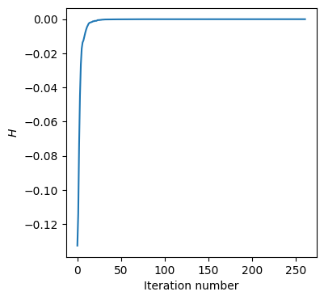

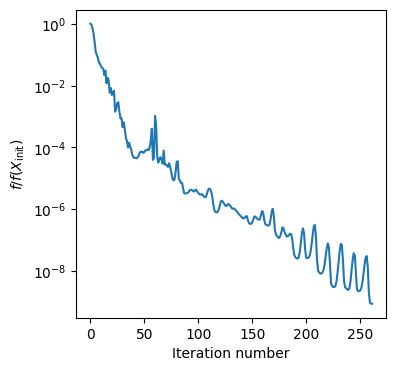

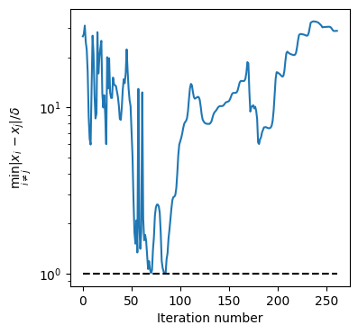

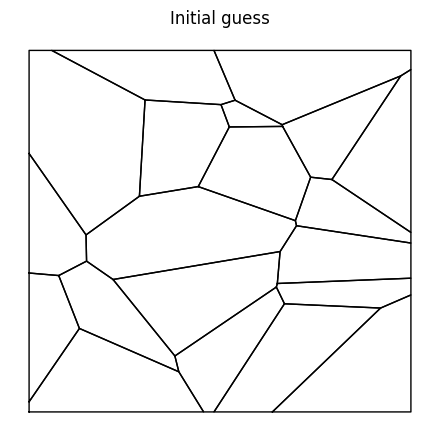

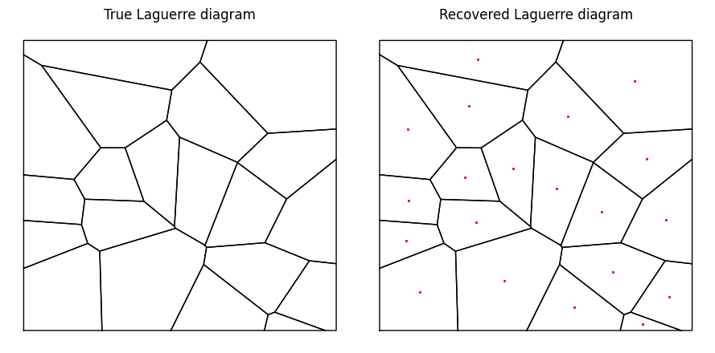

```python
# Plot the results

# Plot the objective function H at each iteration (the true maximum value is 0)
f,ax = plot_H(table)

# Plot the least squares error f at each iteration (the true minimum value is 0)
# (normalised by the initial error)
f, ax = plot_F(table)

# Plot the minimum distance between the seeds at each iteration
f, ax = plot_pairwise(table,d0)

# Plot the random initial guess for the Laguerre diagram
f, ax = plt.subplots(figsize=(4.5,4.5),layout='tight')
w, c = solve_OT_problem(xinit,v,om)
plot_cells(xinit,w,om,ax)
ax.axis('off')
ax.set_title('Initial guess')

# Plot the true Laguerre diagram
f, (ax1,ax2) = plt.subplots(nrows = 1, ncols = 2, figsize = (9,4.5), layout = 'tight')
plot_cells(X0,np.zeros(n),om,ax1)
ax1.axis('off')
ax1.set_title('True Laguerre diagram')

# Plot the recovered Laguerre diagram
w, c = solve_OT_problem(Xf,v,om)
plot_cells(Xf,w,om,ax2)
ax2.axis('off')
ax2.scatter(b[:,0],b[:,1],color='b',s=1) # target centroids in blue
ax2.scatter(c[:,0],c[:,1],color='r',s=1) # centroids of the recovered cells in red
ax2.set_title('Recovered Laguerre diagram');
```

### 3.2 Numerical experiments from Section 5.2 of https://arxiv.org/pdf/2406.00871

In this section we fit a Laguerre tessellation to synthetic area and centroid data that is obtained by perturbing a Voronoi diagram. First we consider a small perturbation (Section 5.2.1 of https://arxiv.org/pdf/2406.00871).

```python
# Code to perform the numerical experiments in Section 5.2.1
# of https://arxiv.org/pdf/2406.00871

Lx = 1 # width of the rectangular box
Ly = 1 # height of the rectangular box

n = 20 # number of seeds

x_seed = 999 # seed for the random number generator for the seeds
p_seed=1002 # seed for the random number generator for the perturbations
amp=0.001 # maximum amplitude of the perturbation

# Generate synthetic data by perturbing the centroids of a Voronoi diagram
v, b, om, X0 = generate_perturbed_voronoi_data(Lx, Ly, n, x_seed = x_seed,
                                               p_seed = p_seed, amp = amp)

# Initial guess for the optimisation method
xinit = b # target centroids

# Tolerances for the optimisation method
ptol = 1e-10
d0 = 1e-3 # minimum distance between the seeds
R0 = np.sqrt(Lx*Ly*n)
maxiter = 1000 # maximum number of iterations

# Fit a Laguerre diagram to the data by maximising H
table, Xf = max_H_solver(xinit, b, v, om, R0 = R0, d = d0, max_iter = maxiter,
                         ptol = ptol, verbosity = True, table = None)
```

```
Intial value of f is 0.003277007916528405
1: H=-4.503588038967134e-05, f = 0.0029352074756517485, minPairwise=0.007896280159889192
2: H=-1.4234564279944181e-05, f = 0.0016091487613477697, minPairwise=0.007862673714507294
3: H=1.9312134600904215e-05, f = 0.00143018494407825, minPairwise=0.007769205925294817
4: H=2.2459838696799032e-05, f = 0.000944778920327774, minPairwise=0.007768217273378925
5: H=3.074314930623403e-05, f = 0.00044610179531308933, minPairwise=0.007733231525714029
6: H=4.134923111854573e-05, f = 0.0004712390447790597, minPairwise=0.007643067171845033
7: H=4.614898442815128e-05, f = 0.0006713373441903598, minPairwise=0.007568516128898418
8: H=4.926515815113864e-05, f = 0.0006598655464561074, minPairwise=0.007514025874306782
9: H=5.2843047921895356e-05, f = 0.0005013687895052866, minPairwise=0.007451430909393501
10: H=5.6627048433879566e-05, f = 0.00037412532890429345, minPairwise=0.007385016571994821
11: H=6.190803510167027e-05, f = 0.0003344018442176557, minPairwise=0.007284189426811544
12: H=6.58639215190541e-05, f = 0.0003244931696774555, minPairwise=0.007190681864541066
13: H=6.736588480251998e-05, f = 0.00029531628071735404, minPairwise=0.007148632418493248
14: H=6.878330270851835e-05, f = 0.0002635622992269554, minPairwise=0.007105370057297705
```

[output cut: 421 more lines]

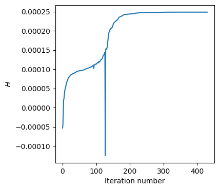

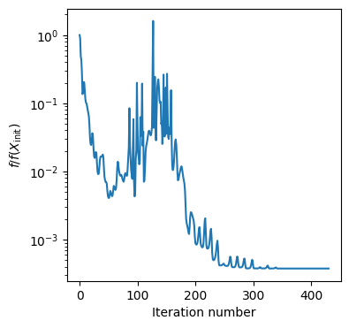

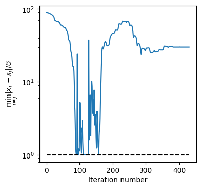

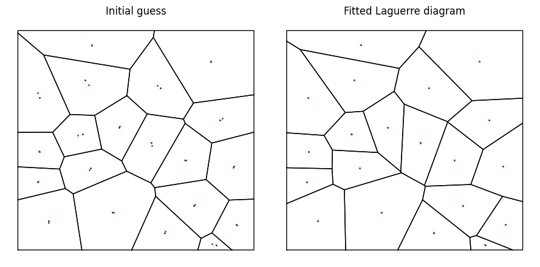

```python
# Plot the results

# Plot the objective function H at each iteration
f,ax = plot_H(table)

# Plot the least squares error f at each iteration
# (normalised by the initial error)
f, ax = plot_F(table)

# Plot the minimum distance between the seeds at each iteration
f, ax = plot_pairwise(table,d0)

# Plot the initial guess for the Laguerre diagram
f, (ax1,ax2) = plt.subplots(nrows = 1, ncols = 2, figsize = (9,4.5), layout = 'tight')
w, c = solve_OT_problem(xinit,v,om)
plot_cells(xinit,w,om,ax1)
ax1.axis('off')
ax1.scatter(b[:,0],b[:,1],color='b',s=1) # target centroids in blue
ax1.scatter(c[:,0],c[:,1],color='r',s=1) # actual centroids in red
ax1.set_title('Initial guess')

# Plot the fitted Laguerre diagram
w, c = solve_OT_problem(Xf,v,om)
plot_cells(Xf,w,om,ax2)
ax2.axis('off')
ax2.scatter(b[:,0],b[:,1],color='b',s=1) # target centroids in blue
ax2.scatter(c[:,0],c[:,1],color='r',s=1) # centroids of the recovered cells in red
ax2.set_title('Fitted Laguerre diagram');
```

Now we consider a larger perturbatoin (Section 5.2.2 of https://arxiv.org/pdf/2406.00871).

```python
# Code to perform the numerical experiments in Section 5.2.2
# of https://arxiv.org/pdf/2406.00871

Lx = 1 # width of the rectangular box
Ly = 1 # height of the rectangular box

n = 20 # number of seeds

x_seed = 999 # seed for the random number generator for the seeds
p_seed=1002 # seed for the random number generator for the perturbations
amp=0.05 # maximum amplitude of the perturbation

# Generate synthetic data by perturbing the centroids of a Voronoi diagram
v, b, om, X0 = generate_perturbed_voronoi_data(Lx, Ly, n, x_seed = x_seed,
                                               p_seed = p_seed, amp = amp)

# Initial guess for the optimisation method
xinit = b # target centroids

# Tolerances for the optimisation method
ptol = 1e-10
d0 = 1e-3 # minimum distance between the seeds
R0 = np.sqrt(Lx*Ly*n)
maxiter = 1000 # maximum number of iterations

# Fit a Laguerre diagram to the data by maximising H
table, Xf = max_H_solver(xinit, b, v, om, R0 = R0, d = d0, max_iter = maxiter,
                         ptol = ptol, verbosity = True, table = None)
```

```
Intial value of f is 0.011186706671570117
1: H=0.0050928414628061, f = 0.010776814389203427, minPairwise=0.003990728950982747
2: H=0.0052221950375112534, f = 0.009239478832129782, minPairwise=0.003557798577376793
3: H=0.005673424726008917, f = 0.015596699695389479, minPairwise=0.0019003127915071425
4: H=0.006027674757249704, f = 0.04289327267720109, minPairwise=0.000699706603088265
5: H=0.006204990375973891, f = 0.06017618381461456, minPairwise=0.000724243767346589
6: H=0.006428985166288995, f = 0.059781849250311, minPairwise=0.0007919879757829976
7: H=0.006974117600780372, f = 0.07815663938005951, minPairwise=0.0006187343471353643
8: H=0.0071587847175054245, f = 0.046533766300460855, minPairwise=0.00032741848780239315
9: H=0.007411242818182161, f = 0.02619589444237308, minPairwise=0.00029691162094054954
10: H=0.008108507698781589, f = 0.01861605101887959, minPairwise=0.0007000198290889754
11: H=0.009637708002988195, f = 0.033669676060644964, minPairwise=0.0012851324693165494
12: H=0.01056107689864334, f = 0.07359706687523669, minPairwise=0.0003978727045321319
13: H=0.010778871198282155, f = 0.30586613576654725, minPairwise=0.0018691228687092909
14: H=0.011882442586893194, f = 0.10963614934619687, minPairwise=0.002038370917515177
```

[output cut: 224 more lines]

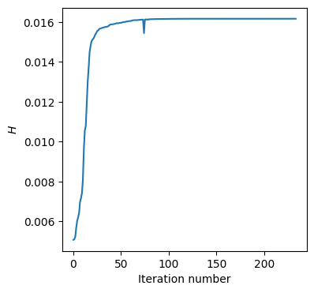

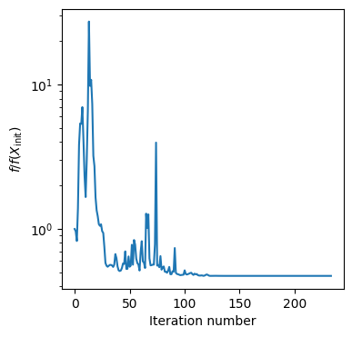

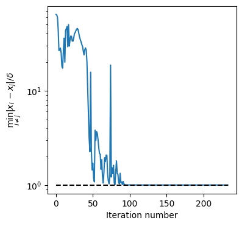

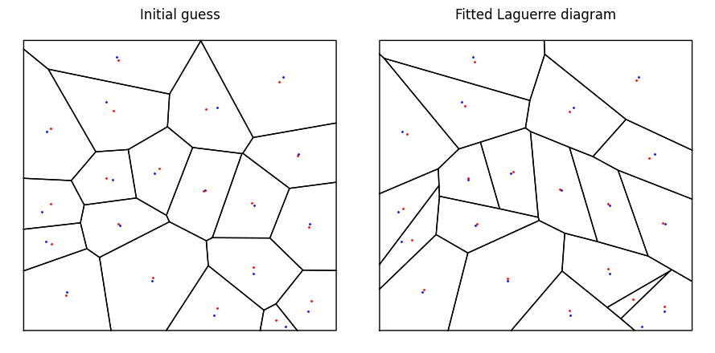

```python
# Plot the results

# Plot the objective function H at each iteration
f,ax = plot_H(table)

# Plot the least squares error f at each iteration
# (normalised by the initial error)
f, ax = plot_F(table)

# Plot the minimum distance between the seeds at each iteration
f, ax = plot_pairwise(table,d0)

# Plot the initial guess for the Laguerre diagram
f, (ax1,ax2) = plt.subplots(nrows = 1, ncols = 2, figsize = (9,4.5), layout = 'tight')
w, c = solve_OT_problem(xinit,v,om)
plot_cells(xinit,w,om,ax1)
ax1.axis('off')
ax1.scatter(b[:,0],b[:,1],color='b',s=1) # target centroids in blue
ax1.scatter(c[:,0],c[:,1],color='r',s=1) # actual centroids in red
ax1.set_title('Initial guess')

# Plot the fitted Laguerre diagram
w, c = solve_OT_problem(Xf,v,om)
plot_cells(Xf,w,om,ax2)
ax2.axis('off')
ax2.scatter(b[:,0],b[:,1],color='b',s=1) # target centroids in blue
ax2.scatter(c[:,0],c[:,1],color='r',s=1) # centroids of the recovered cells in red
ax2.set_title('Fitted Laguerre diagram');
```

### 3.3 Numerical experiments from Section 5.3 of https://arxiv.org/pdf/2406.00871

In this section we fit a Laguerre tessellation to EBSD data.

```python
# Load the EBSD data file EBSD_data.txt
if RunningInCOLAB:
    from google.colab import files
    uploaded = files.upload()
```

Upload widget is only available when the cell has been executed in the current browser session. Please rerun this cell to enable.

```
Saving EBSD_data.txt to EBSD_data.txt
```

```python
EBSD = np.loadtxt("EBSD_data.txt")

# Number of grains
n = np.shape(EBSD)[0]
print('Number of grains =',n)

# Areas of the grains
target_areas = EBSD[:,3]

# Centroids of the grains - we will use these as the seeds
target_centroids = EBSD[:,1:3]

# Area and size of the box
total_area = target_areas.sum()
box_size = np.sqrt(total_area)
print('Box size in microns =',box_size)

# The rectangular domain
OmegaEBSD = ConvexPolyhedraAssembly()
OmegaEBSD.add_box([0,0],[box_size,box_size])

# Ensure that that the target areas sum to the area of the box
target_areas = target_areas*box_size**2/total_area
v, b = make_data_compatible(target_areas,target_centroids,OmegaEBSD)
```

```
Number of grains = 243
Box size in microns = 251.25443279671703
```

```python
# Code to perform the numerical experiment in Section 5.3
# of https://arxiv.org/pdf/2406.00871

# Initial guess for the optimisation method
xinit = b # target centroids

# Tolerances for the optimisation method
ptol = 1e-8
d0 = 1e-3 # minimum distance between the seeds
maxiter = 10000 # maximum number of iterations

# Fit a Laguerre diagram to the EBSD data by minimising f
table, Xf = min_F_solver(xinit, b, v, OmegaEBSD, d=d0, max_iter=maxiter,
                         ptol = ptol, verbosity = True, table = None)
```

```
Intial value of f is 0.01630817365747469
1: f = 0.01630377539883459, minPairwise=4.317292794090427
2: f = 0.016281820622173024, minPairwise=4.317294261916098
3: f = 0.016172953746489034, minPairwise=4.317301726571726
4: f = 0.01565099502523234, minPairwise=4.317338636393598
5: f = 0.01356279371899663, minPairwise=4.317513633485815
6: f = 0.011300428006735074, minPairwise=4.3179961371914874
7: f = 0.011283598193841591, minPairwise=4.317958077372208
8: f = 0.011282309726529072, minPairwise=4.317959070801346
9: f = 0.011275684944873273, minPairwise=4.317961030833813
10: f = 0.011242744514032428, minPairwise=4.317969973620671
11: f = 0.011082791605116717, minPairwise=4.318014478482322
12: f = 0.010395120115084082, minPairwise=4.318229218177295
13: f = 0.0090280550561028, minPairwise=4.31911317250174
14: f = 0.009017900073242427, minPairwise=4.3191809254417075
```

[output cut: 428 more lines]

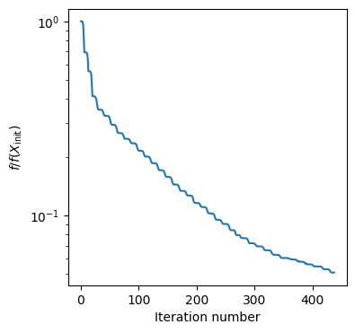

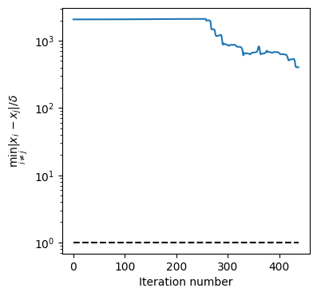

```python
# Plot the results

# Plot the least squares error f at each iteration
# (normalised by the initial error)
f, ax = plot_F(table)

# Plot the minimum distance between the seeds at each iteration
f, ax = plot_pairwise(table,d0)
```

Upload widget is only available when the cell has been executed in the current browser session. Please rerun this cell to enable.

```
Saving EBSD_image.png to EBSD_image.png
```

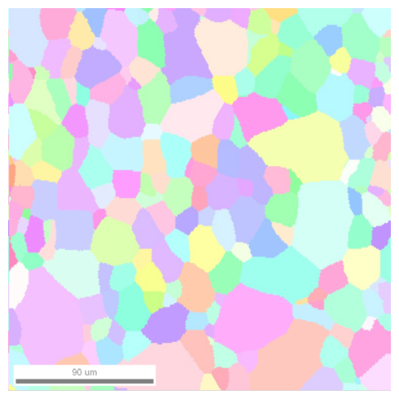

```python
# Load EBSD_image.png
if RunningInCOLAB:
    from google.colab import files
    uploaded = files.upload()

# Plot the EBSD image
f, ax = plt.subplots(figsize=(5,5),layout='tight')
ax.axis("off")
im = plt.imread('EBSD_image.png')
implot = ax.imshow(im,alpha=0.5,zorder=-1,extent=(0,box_size,0,box_size),origin='lower')
ax.invert_yaxis()
```

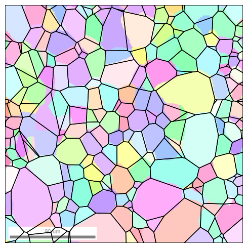

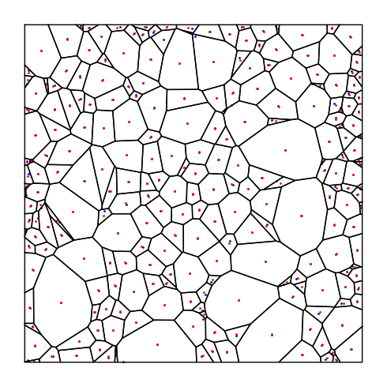

```python
# Plot the fitted Laguerre diagram overlaid on the EBSD image
f, ax = plt.subplots(figsize=(5,5),layout='tight')
w, c = solve_OT_problem(Xf,v,OmegaEBSD)
plot_cells(Xf,w,OmegaEBSD,ax)
ax.axis("off")
im = plt.imread('EBSD_image.png')
implot = ax.imshow(im,alpha=0.5,zorder=-1,extent=(0,box_size,0,box_size),origin='lower')
ax.invert_yaxis()

# Plot the Laguerre diagram, target centroids (in blue), and actual centroids (in red)
f, ax = plt.subplots(figsize=(5,5),layout='tight')
plot_cells(Xf,w,OmegaEBSD,ax)
ax.axis("off")
ax.invert_yaxis()
ax.scatter(b[:,0],b[:,1],color='b',s=1) # target centroids from EBSD data
ax.scatter(c[:,0],c[:,1],color='r',s=1) # actual centroids of Laguerre cells
```